# cranscurb: an R package that provide a clearn version of cran downloads

Danyang Dai

Monash University  
danyang.dai@monash.edu

Emi Tanaka

Monash University  
emi.tanaka@monash.edu

Abstract

# 1 Introduction

With the growth of R community, many R packages have been developed as research products. Hornik, Murdoch, and Zeileis (2012) said that “R packages are the result of scholarly activity and as such constitute scholarly resources which must be clearly identifiable for the respective scientific communities”. Majority of the R packages are developed and owned by individual author who has been contributing and sharing their knowledge with the public. It is important to recognise the contribution that these R package developers made to the scientific and academic communities. One of the most important metric for scholarly and scientific research publications is download statistics (Greene 2016). Similar to publications, the download statistics is an important part of the metric. Li (2020) suggests that download counts are a popular way that indicates a package’s importance and quality.

To use the R package download statistics as a metric, it must be accurate to be useful and reliable for any purposes such as grant application. As the number of R package downloads is calculated according to the CRANlog entries, the challenge here is to identify whether it is an actual user behind each entry.

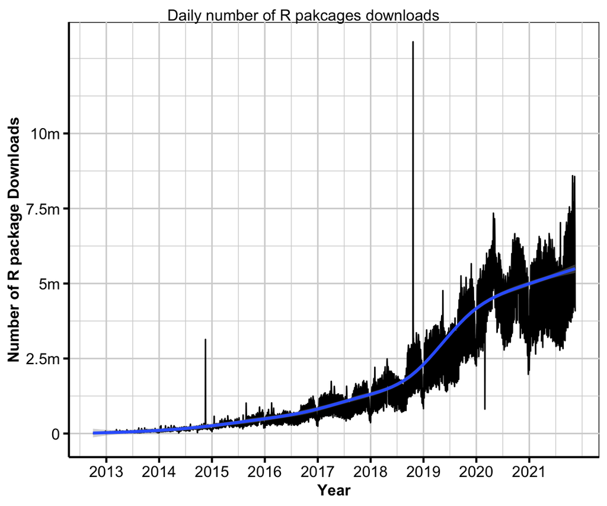

```
## 134 codes from your data successfully matched countries in the map
## 6 codes from your data failed to match with a country code in the map
## 107 codes from the map weren't represented in your data
```

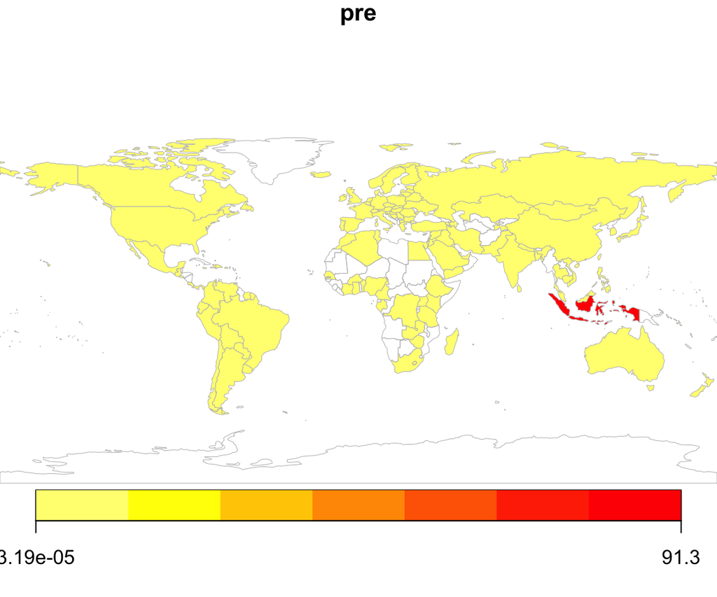

Figure shows the daily total number of R packages downloads from October 2012 to November 2021. From the plot, it suggests that there has been an enormous growth of R package downloads overtime. Among the growth of the number of downloads, there are two spikes observed. Zooming in for a closer look at the two spikes, the first one happened on 17th of November 2014. On the 17th of November 2014, 91.31% of the R packages downloads are done by the IP address from Indonesia.

# 2 The CRAN log files

# 3 Data cleaning and processing

# 4 Demo of cranscrub functions

# 5 Comparison of the scrubbed with the orginal data

# Discussion

Greene, Joseph W. 2016. “Web Robot Detection in Scholarly Open Access Institutional Repositories.” *Library Hi Tech* 34 (3): 500–520.

Hornik, Kurt, Duncan Murdoch, and Achim Zeileis. 2012. “Who Did What? The Roles of r Package Authors and How to Refer to Them.” *The R Journal* 4 (1): 64–69.

Li, Peter. 2020. *Counting and Visualizing CRAN Downloads with packageRank (with Caveats!)*. R-bloggers. https://www.r-bloggers.com/2020/05/counting-and-visualizing-cran-downloads-with-packagerank-with-caveats/.